# Chapter 12 Controversies in Trade Policy

# Preview

- Arguments for “activist” trade policies
  - Externality or appropriability problem
  - Strategic trade policy with imperfect competition
- Arguments concerning trade and people
  - Trade and low-wage labor
  - Trade and the environment
  - Trade and culture

# Sophisticated Arguments for Activist Trade Policy

# Arguments for an Activist Trade Policy

- An activist trade policy usually means government policies that actively support export industries through subsidies.
- Arguments for activist trade policies use an assumption that import-substituting industrialization (Chapter 11) and the cases against free trade (Chapter 9) used: market failure.
  - Externalities or an appropriability problem
  - Imperfect competition that results in revenues that exceed all (opportunity) costs: “excess” profits.

# Technology and Externalities

- Firms that invest in new technology generally create knowledge that other firms can use without paying for it: an appropriability problem.
  - By investing in new technology, firms are creating an extra benefit for society that is easily used by others.
  - An appropriability problem is an example of an **externality**: benefits or costs that accrue to parties other than the one that generates it.
  - An externality implies that the marginal social benefit of investment is not represented by producer surplus.

# Technology and Externalities

- Governments may want to actively encourage investment in technology when externalities in new technologies create a high marginal social benefit.
- Should the U.S. government subsidize high- technology industries?

# Technology and Externalities

- When considering whether a government should subsidize high-technology industries, consider:
  1. The ability of governments to subsidize the right activity.
     - Much activity by high technology firms has nothing to do with generating knowledge: subsidizing equipment purchases or non-technical workers generally does not create new technology.
     - Knowledge and innovation are created in industries that are not usually classified as high tech.

# Technology and Externalities

2. Instead of subsidizing specific industries, the U.S. subsidizes research and development through the tax code.
   - Research and development expenses can be deducted from corporate taxable income.
3. The economic importance of externalities.
   - It is difficult to determine the quantitative importance that externalities have on the economy.
   - Therefore, it is difficult to say how much to subsidize activities that create externalities.

# Technology and Externalities

4. Externalities may occur across countries as well.
   - No individual country has an incentive to subsidize industries if all countries could take advantage of the externalities generated in a country.

# Technology and Externalities

- Some argue that the United States should have a deliberate policy of promoting high-technology industries and helping them compete against foreign rivals.
- Fear in the 1980s that Japan’s dominance of the semiconductor memory market would translate into a broader dominance of computers and related technologies proved to be unfounded.

# Technology and Externalities

- More recently, the decline in U.S. employment in the information, communication, and technology (ICT) industries, which are at the heart of the information technology revolution, and large U.S. trade deficits in ICT goods have renewed fears.

# The U.S. Trade Balance in Information Goods

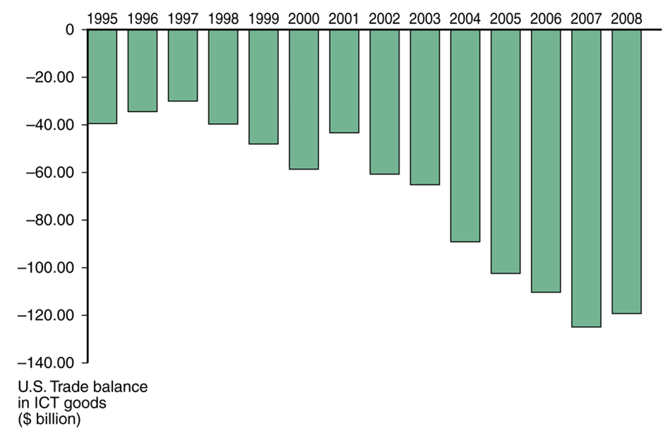

# U.S. Manufacturing Employment

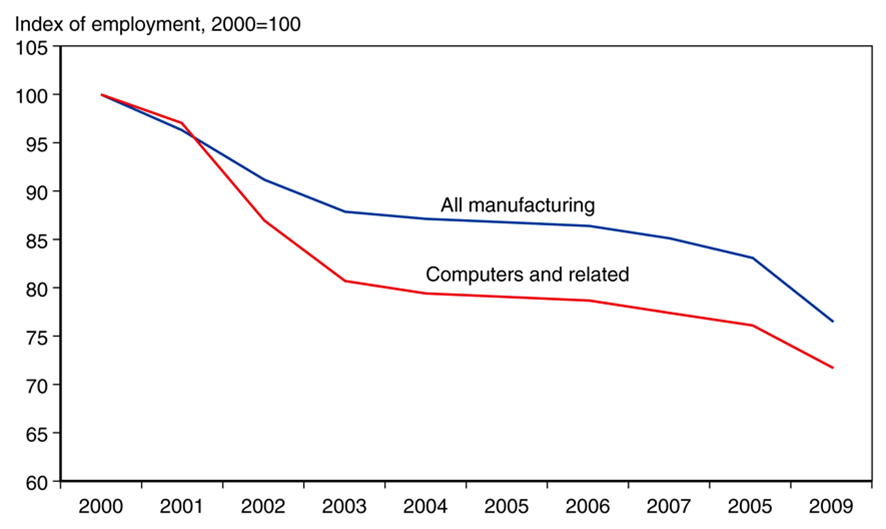

# Imperfect Competition and Strategic Trade Policy

- Imperfectly competitive industries are typically dominated by a few firms that generate monopoly profits or **excess profits**.
  - Excess profits are revenues that exceed all opportunity costs: profits higher than what equally risky investments elsewhere in the economy earn.
- In an imperfectly competitive industry, government subsidies can shift excess profits from a foreign firm to a domestic firm.

# Imperfect Competition and Strategic Trade Policy

- Example (called the Brander-Spencer analysis):
  - Two firms (Boeing and Airbus) compete in the international market but are located in two different countries (U.S. and EU).
  - Both firms manufacture airplanes, but each firm’s profits depends on the actions of the other.
  - Each firm decides to produce or not depending on profit levels.

# Two-Firm Competition

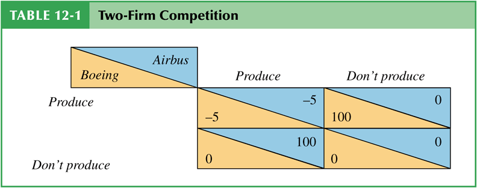

# Imperfect Competition and Strategic Trade Policy

- The predicted outcome depends on which firms invest/produce first.
  - If Boeing produces first, then Airbus will not find it profitable to produce.
  - If Airbus produces first, then Boeing will not find it profitable to produce.
- But a subsidy by the European Union can alter the outcome by making it profitable for Airbus to produce *regardless of Boeing’s action*.

# Effects of a Subsidy to Airbus

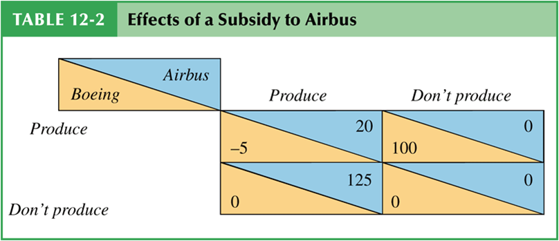

# Imperfect Competition and Strategic Trade Policy

- If Boeing expects that the European Union will subsidize Airbus, Boeing will be deterred from entering the industry.
  - Thus, the subsidy of 25 will generate profits of 125 for Airbus.
  - The subsidy raises profits more than the amount of the subsidy itself due to its deterrent effect on foreign competition.

# Imperfect Competition and Strategic Trade Policy

- A government policy to give a domestic firm a strategic advantage in production is called a **strategic trade policy**.

# Imperfect Competition and Strategic Trade Policy

- Criticisms of this analysis include:
  1. Practical use of strategic trade policy requires more information about firms than is likely available.
     - The predictions from the simple example differ if the numbers are slightly different.
     - What if governments or economists are not exactly right when predicting the profits of firms?
       - For example, what if Boeing has a better technology that only it can recognize, so that even if Airbus produces, Boeing still finds it profitable to produce?

# Imperfect Competition and Strategic Trade Policy

2. Foreign retaliation also could result:
   - If the European Union subsidizes Airbus, the U.S. could subsidize Boeing, which would deter neither firm from producing, start a trade war, and waste taxpayer funds.
3. Strategic trade policy, like any trade policy, could be manipulated by politically powerful groups.

# Globalization and Low-Wage Labor

# Trade and Low-Wage Labor

- Manufactured exports from low- and middle- income countries have been increasing.
- Compared to rich-country standards, workers who produce these goods are paid low wages and may work under poor conditions.
- Some have opposed free trade for this reason.

# Trade and Low-Wage Labor

- One example of this situation is the *maquiladora* sector: Mexican firms that produce for export to the U.S.
- Opponents of the North American Free Trade Agreement have argued that it is now easier for employers to replace high-wage workers in the U.S. with low-wage workers in Mexico.

# Trade and Low-Wage Labor

- The above claim can be true, but we cannot conclude that trade hurts workers.
- A Ricardian model predicts that while wages in Mexico should remain lower than those in the U.S. due to low productivity in Mexico, they will rise relative to their pretrade level.
- A Heckscher-Ohlin model does predict that unskilled workers in the U.S. will lose from NAFTA, but it also predicts that unskilled workers in Mexico will gain.

# Trade and Low-Wage Labor

- Despite the low wages earned by workers in Mexico, both theories predict that those workers are better off with trade than they would be if trade had not taken place.
  - Evidence consistent with these predictions would show that wages in *maquiladoras* have risen relative to wages in other Mexican sectors.
  - One could also compare working conditions in *maquiladoras* with the working conditions in other Mexican sectors, rather than with those in the U.S.

# Real Wages

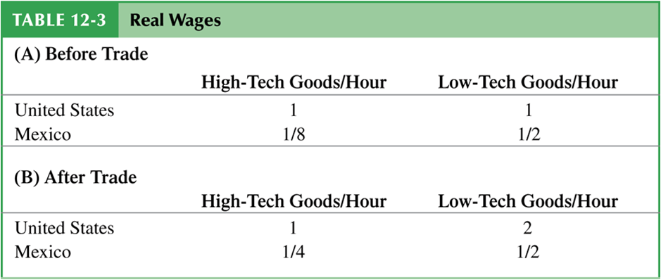

# Trade and Low-Wage Labor

- Some labor activists want to include labor standards in trade negotiations.
  - However, labor standards imposed by foreign countries are opposed by governments of low- and middle-income countries.
  - International standards could be used as a protectionist policy or a basis for lawsuits when domestic producers did not meet them.
  - Standards set by high-income countries would be expensive for low- and middle-income producers.

# Trade and Low-Wage Labor

- A policy that could be agreeable for governments of low- and middle-income countries is a system that monitors wages and working conditions and makes this information available to consumers.
  - Products could be certified as made with acceptable wage rates and working conditions.
  - But this policy would have a limited effect, since a large majority of workers in low- and middle-income countries do not work in the export sector.

# Globalization and the Environment

# Trade and the Environment

- Compared to rich-country standards, environmental standards in low- and middle- income countries are lax.
- Some have opposed free trade for this reason.
- But we cannot conclude that trade hurts the environment, since consumption and production in the absence of trade have degraded the environment.

# Trade and the Environment

- Some environmental activists want to include environmental standards in trade negotiations.
  - However, environmental standards imposed by foreign countries are opposed by governments of low- and middle-income countries.
  - International standards could be used as a protectionist policy or a basis for lawsuits when domestic producers did not meet them.
  - Standards set by high-income countries would be expensive for low- and middle-income producers.

# Trade and the Environment

- As poor countries grow richer, possibly partly due to trade, they produce more and can consume more, leading to more environmental degradation.
- But as countries grow richer, they want to pay for more stringent environment protection.
- Both of these ideas are represented as an **environmental Kuznets curve**:
  - an inverted “U-shaped” relationship between environmental degradation and income per person

# The Environmental Kuznets Curve

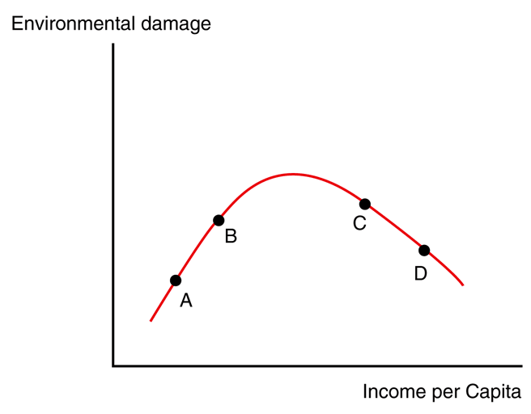

# Trade and the Environment

- Because rich countries usually have strict environmental regulations and poor countries do not, environmentally hazardous activities may be moved to poor countries.
  - A **pollution haven** is a place where an economic activity that is subject to strict environmental controls in some countries is moved to (sold to) other countries with less strict regulation.
  - Yet, there is evidence that pollution havens are insignificant relative to the pollution that occurs without international trade.

# Carbon Dioxide Emissions

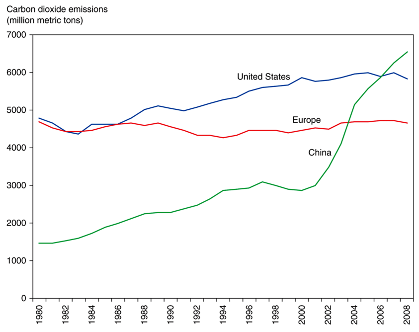

# Trade and the Environment

- Pollution in some countries may cause a negative externality for other countries.
  - For example, production in China could cause air pollution in Korea (or on the West Coast of the U.S.).
  - To the degree that pollution causes negative externalities for other countries, they should want to include it in international negotiations.
  - Emissions of carbon dioxide is an example of pollution that causes a negative externality and that has been included in international negotiations.

# Trade and Culture

- Some activists believe that trade destroys culture in other countries.
  - This belief neglects the principle that we should allow people to define their culture through the choices that *they* make, not through standards set by others.
  - Also, any economic change, not just trade, leads to changes in everyday life.

# Summary

# Summary

1. One argument for an activist trade policy is that investment in high-technology industries produces externalities for the economy.
   - But it is hard to identify which activities produce externalities and if so, to what degree they do.
2. A second argument for an activist trade policy is that governments can give domestic firms a strategic advantage in industries with excess profits.
   - But it is unclear if such a policy would succeed at giving a firm a strategic advantage or if it would be worthwhile.

# Summary

3. Some have opposed free trade because of the fact that workers in low- and middle-income countries earn lower wages and have worse working conditions than workers in high-income countries.
   - But workers in low- and middle-income countries are predicted to have lower wages due to lower productivity, yet still have higher wages compared to their situation without trade.
4. Some have proposed that trade negotiations should involve labor, environmental, or “cultural” standards, but these standards are generally opposed by governments of low- and middle- income countries.